# Sentiment analysis of a novel

J.M.T. Roos

Last updated: 2020-05-11 11:42:19

Install package `gutenbergr`

```r
install.packages("gutenbergr", dependencies = TRUE)
```

Load the library and the tidyverse

```r
library(gutenbergr)
library(tidyverse)
```

Get a list of H.P. Lovecraft books

```r
gutenberg_works(gutenberg_author_id == 34724, distinct = FALSE)
```

```
## # A tibble: 3 x 8
##   gutenberg_id title author gutenberg_autho… language
##          <int> <chr> <chr>             <int> <chr>
## 1        30637 Writ… Lovec…            34724 en
## 2        31469 The … Lovec…            34724 en
## 3        50133 The … Lovec…            34724 en
## # … with 3 more variables: gutenberg_bookshelf <chr>,
## #   rights <chr>, has_text <lgl>
```

Download a book

```r
dunwich <- gutenberg_download(50133)
```

Take a look

```r
dunwich$text %>% head(10)
```

```
##  [1] "                       _The_ Dunwich Horror"
##  [2] ""
##  [3] "                        by H. P. LOVECRAFT"
##  [4] ""
##  [5] ""
##  [6] "     \"Gorgons, and Hydras, and Chimeras--dire stories of Cel\xe6no and"
##  [7] "     the Harpies--may reproduce themselves in the brain of"
##  [8] "     superstition--_but they were there before_. They are transcripts,"
##  [9] "     types--the archetypes are in us, and eternal. How else should the"
## [10] "     recital of that which we know in a waking sense to be false come"
```

```r
dunwich_2 <- dunwich %>% filter(text != "" & !str_detect(text,
    "^[0-9]+$"))
dunwich_2 %>% select(text) %>% as.data.frame %>% head(30)
```

```
##                                                                       text
## 1                                                     _The_ Dunwich Horror
## 2                                                       by H. P. LOVECRAFT
## 3        "Gorgons, and Hydras, and Chimeras--dire stories of Cel\xe6no and
## 4                    the Harpies--may reproduce themselves in the brain of
## 5        superstition--_but they were there before_. They are transcripts,
## 6        types--the archetypes are in us, and eternal. How else should the
## 7         recital of that which we know in a waking sense to be false come
## 8        to affect us at all? Is it that we naturally conceive terror from
## 9              such objects, considered in their capacity of being able to
## 10         inflict upon us bodily injury? Oh, least of all! _These terrors
## 11           are of older standing. They date beyond body_--or without the
## 12      body, they would have been the same.... That the kind of fear here
## 13      treated is purely spiritual--that it is strong in proportion as it
## 14       is objectless on earth, that it predominates in the period of our
```

[output cut: 16 more lines]

Fix encoding problems

```r
dunwich_3 <- dunwich_2$text %>% stringi::stri_encode(., from = "ISO-8859-1",
    to = "UTF-8")
```

Download the VAD data used to score words based on their emotional content

```r
VAD_scores_url <- "http://crr.ugent.be/papers/Ratings_Warriner_et_al.csv"
VAD <- readr::read_csv(VAD_scores_url) %>% select(Word, valence = V.Mean.Sum,
    arousal = A.Mean.Sum, dominance = D.Mean.Sum)
```

## Line-by-line analysis using `tm`

Load the `tm` package

```r
library(tm)
```

Create a vector corpus

```r
dunwich_corpus <- dunwich_3 %>% VectorSource() %>% Corpus()
dunwich_corpus
```

```
## <<SimpleCorpus>>
## Metadata:  corpus specific: 1, document level (indexed): 0
## Content:  documents: 1531
```

Clean things up (note: we are not stemming words)

```r
dunwich_corpus_cleaned <- dunwich_corpus %>%
  tm_map(content_transformer(tolower)) %>%      # lower case
  tm_map(removePunctuation) %>%                 # remove punctuation
  tm_map(removeWords, stopwords('english')) %>% # remove common words
  tm_map(stripWhitespace)                       # remove white space
```

Generate a term-document matrix

```r
tdm <- dunwich_corpus_cleaned %>% TermDocumentMatrix
tdm %>% findFreqTerms(lowfreq = 30)
```

```
##  [1] "dunwich"   "one"       "old"       "came"
##  [5] "whateleys" "great"     "hill"      "whateley"
##  [9] "wilbur"    "seemed"    "like"      "armitage"
```

Join with the VAD scores

```r
tdm_long <- with(tdm, tibble(term = i, document = j, count = v)) %>%
    mutate(term = factor(term, labels = Terms(tdm)) %>% as.character)
tdm_scored <- tdm_long %>% inner_join(VAD, by = c(term = "Word"))
tdm_scored
```

```
## # A tibble: 4,017 x 6
##    term      document count valence arousal dominance
##    <chr>        <int> <dbl>   <dbl>   <dbl>     <dbl>
##  1 horror           1     1    3.38    6.13      3.49
##  2 brain            4     1    6.22    3.35      6.28
##  3 reproduce        4     1    5.63    4.61      4.88
##  4 eternal          6     1    6.76    3.59      5.41
##  5 come             7     1    5.64    3.57      5.94
##  6 know             7     1    6.82    3.24      5.78
##  7 recital          7     1    4.7     4.2       5.23
##  8 sense            7     1    6.09    3.7       6.29
##  9 affect           8     1    5.65    3.61      6.39
## 10 conceive         8     1    5.63    4.95      5.92
## # … with 4,007 more rows
```

```r
line_scores <- tdm_scored %>% transmute(line = document, valence = valence *
    count, arousal = arousal * count, dominance = dominance *
    count) %>% group_by(line) %>% summarise_all(~sum(.x))
```

Tidy and visualize

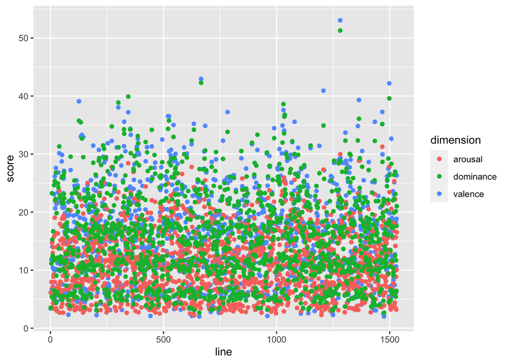

```r
line_scores_2 <- line_scores %>% gather(dimension, score,
    -line)
g <- ggplot(line_scores_2, aes(x = line, y = score, colour = dimension))
g + geom_point()
```

Smooth

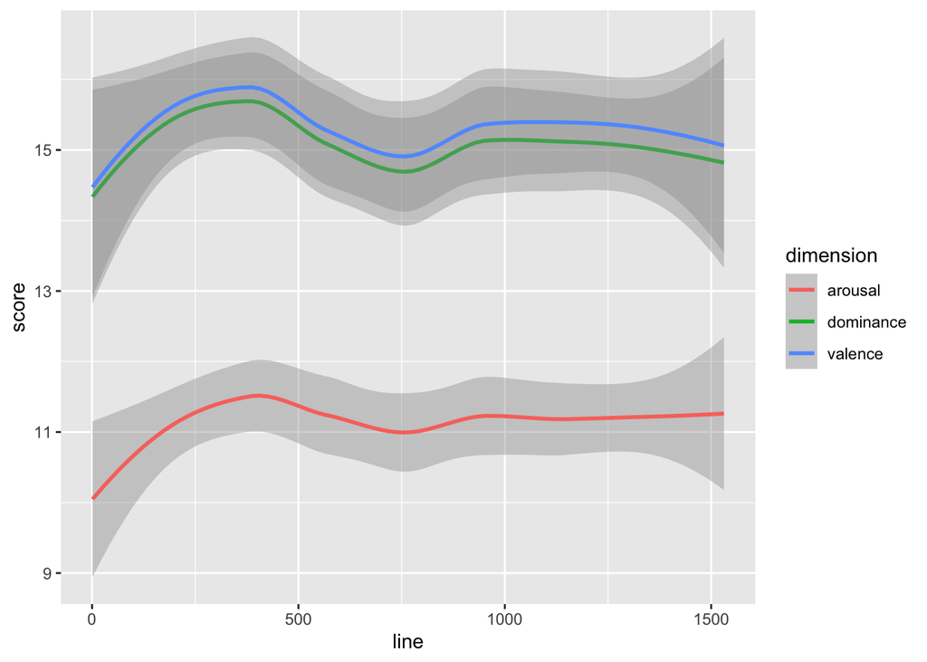

```r
g + stat_smooth(method = "loess")
```

## Sentence- and paragraph-level analysis using `tidytext`

Load the `tidytext` library (installing it if necessary)

```r
# install.packages('tidytext', dependencies = TRUE)
library(tidytext)
```

Create a data frame with each word, and counters for the paragraph and sentence number. Paragraphs are delimited by a single blank line, but to identify sentences, we use the `unnest_tokens` function with `token = 'sentences'`.

```r
dunwich_tokens <- dunwich %>% select(-gutenberg_id) %>% mutate(para_num = cumsum(text ==
    ""), text = stringi::stri_encode(text, from = "ISO-8859-1",
    to = "UTF-8")) %>% unnest_tokens(sentence, text, token = "sentences") %>%
    mutate(sent_num = row_number()) %>% unnest_tokens(word,
    sentence, token = "words") %>% mutate(word = removePunctuation(word))
dunwich_tokens
```

```
## # A tibble: 17,608 x 3
##    para_num sent_num word
##       <int>    <int> <chr>
##  1        0        1 the
##  2        0        1 dunwich
##  3        0        1 horror
##  4        1        2 by
##  5        1        2 h
##  6        1        3 p
##  7        1        4 lovecraft
##  8        3        5 gorgons
##  9        3        5 and
## 10        3        5 hydras
## # … with 17,598 more rows
```

For a paragraph level analysis, we remove stop words, then count the number of times each remaining word appears in each paragraph.

```r
word_counts <- dunwich_tokens %>% anti_join(get_stopwords()) %>%
    count(para_num, word, sort = TRUE) %>% ungroup
word_counts
```

```
## # A tibble: 8,755 x 3
##    para_num word        n
##       <int> <chr>   <int>
##  1        8 one         7
##  2       20 ye          7
##  3       55 man         5
##  4       55 old         5
##  5       55 shall       5
##  6       55 sothoth     5
##  7       55 yog         5
##  8       81 like        5
##  9      102 earth       5
## 10      133 thing       5
## # … with 8,745 more rows
```

Create a DTM from the word counts

```r
dtm <- word_counts %>% cast_dtm(document = para_num, term = word,
    valu = n)
dtm
```

```
## <<DocumentTermMatrix (documents: 161, terms: 3897)>>
## Non-/sparse entries: 8755/618662
## Sparsity           : 99%
## Maximal term length: 17
## Weighting          : term frequency (tf)
```

There are about 160 paragraphs. Try fitting a model with 8 topics to see what falls out…

```r
library(topicmodels)
paragraph_lda <- LDA(dtm, k = 8, control = list(seed = 1234))
```

Visualize the top 5 terms for each topic

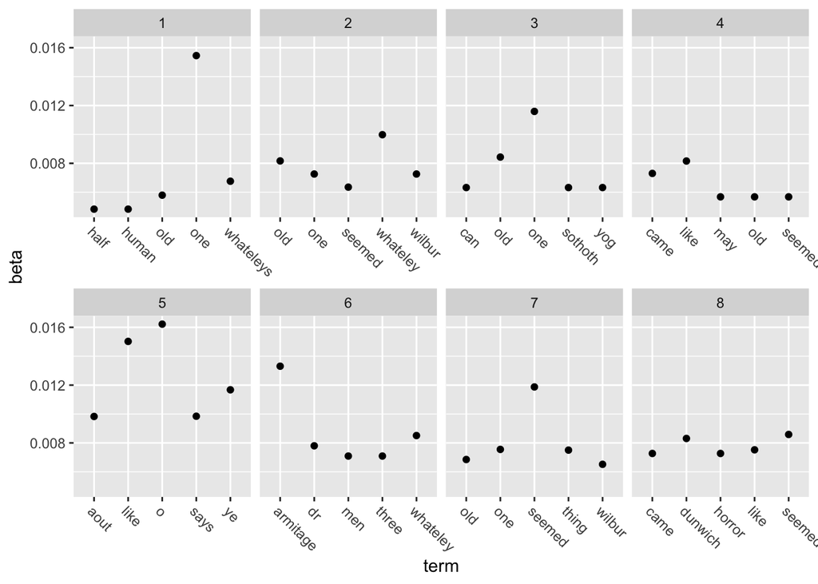

```r
tidy(paragraph_lda, matrix = "beta") %>% group_by(topic) %>%
    top_n(n = 5, wt = beta) %>% filter(row_number() <= 5) %>%
    arrange(topic, -beta) %>% ungroup %>% ggplot(aes(x = term,
    y = beta)) + geom_point() + facet_wrap(~topic, drop = TRUE,
    scale = "free_x", ncol = 4) + theme(axis.text.x = element_text(angle = -45,
    hjust = 0))
```

Visualize the prevalence of topics over the course of the novel

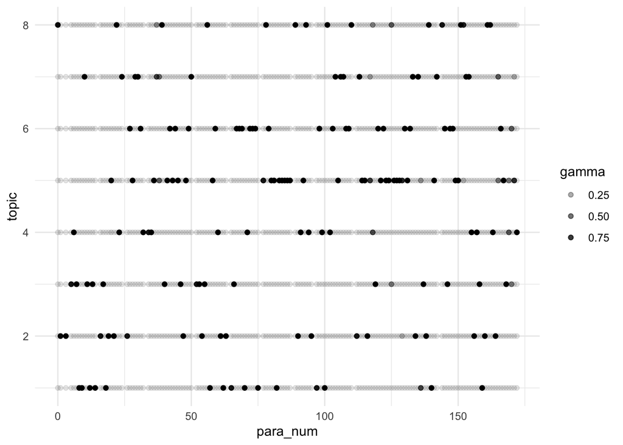

```r
tidy(paragraph_lda, matrix = "gamma") %>% mutate(para_num = as.integer(document)) %>%
    ggplot(aes(x = para_num, y = topic, alpha = gamma)) +
    geom_point() + theme_minimal()
```

## Paragraph- and sentence-level emotional analysis

```r
scored_tokens <- dunwich_tokens %>% inner_join(VAD, by = c(word = "Word"))
scored_tokens
```

```
## # A tibble: 4,415 x 6
##    para_num sent_num word       valence arousal dominance
##       <int>    <int> <chr>        <dbl>   <dbl>     <dbl>
##  1        0        1 horror        3.38    6.13      3.49
##  2        3        5 dire          3       5         4.17
##  3        3        5 may           5.55    3.19      5.94
##  4        3        5 reproduce     5.63    4.61      4.88
##  5        3        5 brain         6.22    3.35      6.28
##  6        3        5 superstit…    4.84    6.14      5.45
##  7        3        6 eternal       6.76    3.59      5.41
##  8        3        7 recital       4.7     4.2       5.23
##  9        3        7 know          6.82    3.24      5.78
## 10        3        7 sense         6.09    3.7       6.29
## # … with 4,405 more rows
```

Score by sentence using max scoring word in each sentence

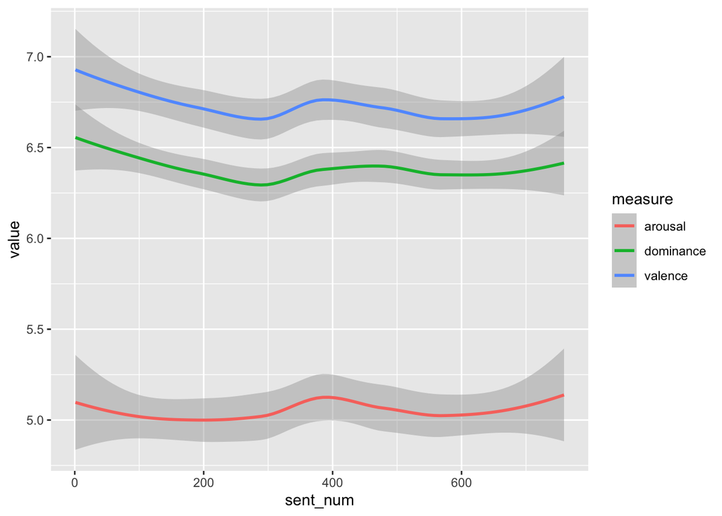

```r
scored_tokens %>% group_by(sent_num) %>% summarise_at(vars(valence,
    arousal, dominance), funs(max)) %>% gather(measure, value,
    -sent_num) %>% ggplot(aes(x = sent_num, y = value, colour = measure)) +
    stat_smooth()
```

Same thing, but score each paragraph as the median score for its sentences

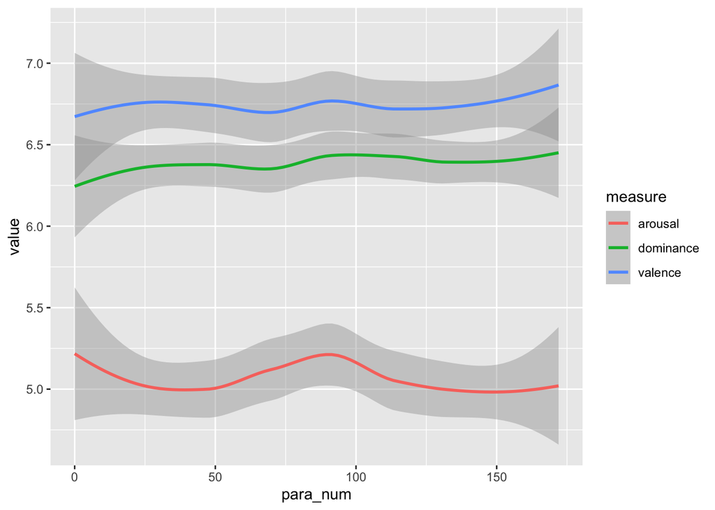

```r
scored_tokens %>% group_by(para_num, sent_num) %>% summarise_at(vars(valence,
    arousal, dominance), funs(max)) %>% group_by(para_num) %>%
    summarise_at(vars(valence, arousal, dominance), funs(median)) %>%
    gather(measure, value, -para_num) %>% ggplot(aes(x = para_num,
    y = value, colour = measure)) + stat_smooth()
```

Simple positive-negative sentiment analysis

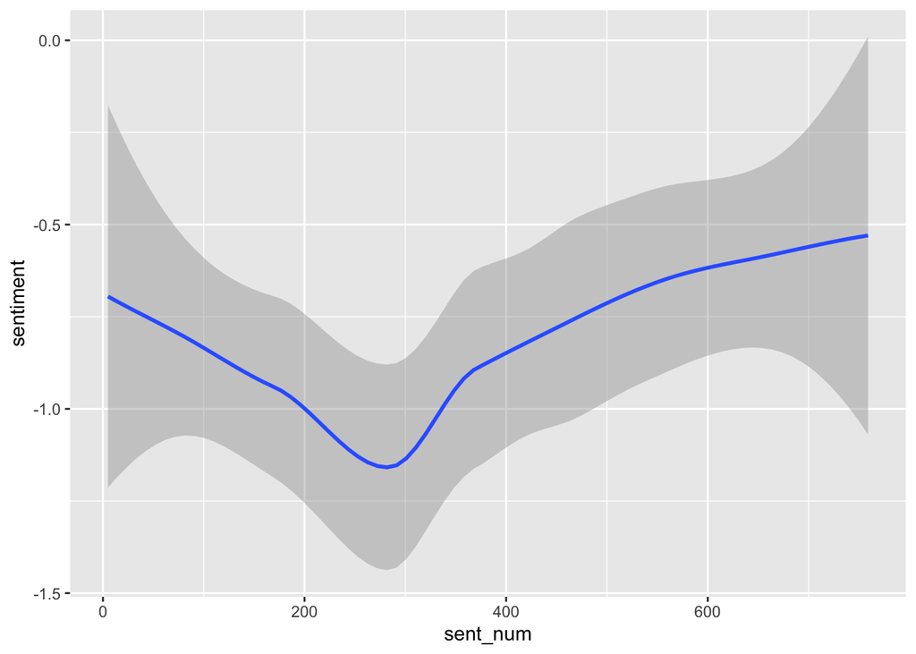

```r
dunwich_tokens %>% inner_join(get_sentiments("bing")) %>%
    count(para_num, sent_num, sentiment) %>% spread(sentiment,
    n, fill = 0) %>% mutate(sentiment = positive - negative) %>%
    ggplot(aes(x = sent_num, y = sentiment)) + geom_smooth()
```

Same thing, but aggregating up to the paragraph level by averaging across sentences

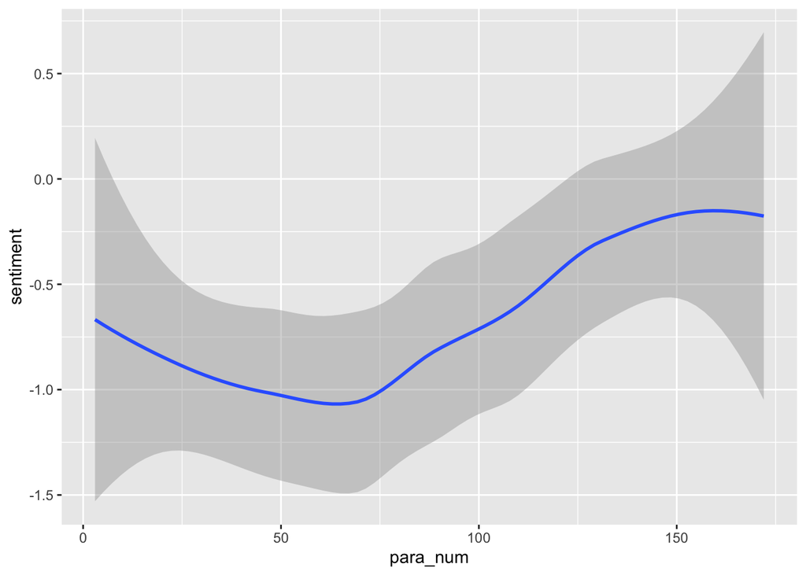

```r
dunwich_tokens %>% inner_join(get_sentiments("bing")) %>%
    count(para_num, sent_num, sentiment) %>% spread(sentiment,
    n, fill = 0) %>% mutate(sentiment = positive - negative) %>%
    group_by(para_num) %>% summarise(sentiment = mean(sentiment)) %>%
    ggplot(aes(x = para_num, y = sentiment)) + geom_smooth()
```